# Explore the RTX data

**J. Taroni 2018**

## Functions and directory set up

```r
# magrittr pipe
`%>%` <- dplyr::`%>%`
source(file.path("util", "plier_util.R"))
source(file.path("util", "test_LV_differences.R"))
```

```r
# plot and result directory setup for this notebook
plot.dir <- file.path("plots", "24")
dir.create(plot.dir, recursive = TRUE, showWarnings = FALSE)
results.dir <- file.path("results", "24")
dir.create(results.dir, recursive = TRUE, showWarnings = FALSE)
```

## Read in data

Specifically, we’ll look at RNA-seq data that’s been processed various ways (e.g., taking into account experimental design or not, etc.).

### Covariate information

```r
covariate.df <- readr::read_tsv(file.path("data", "rtx",
                                          "RTX_full_covariates.tsv"))
```

### Counts

```r
# tximport gene-level data -- includes counts, TPM
gene.summary <- readRDS(file.path("data", "rtx", "tximport.RDS"))
# extract count matrix -- we used `countsFromAbundance = "no"` to generate this
count.matrix <- gene.summary$counts
# log2 transform plus some constant, here 1, to account for zeros
log.count <- log2(count.matrix + 1)
```

### VST - blind to experimental design

```r
vst.blind <- readr::read_tsv(file.path("data", "rtx", "VST_blind.pcl"))
```

### VST - batch, timepoint, responder status

Note that the experimental design we gave the `DESeq2::vst` function may ultimately not be the one we’d like to use.

```r
vst.design <- readr::read_tsv(file.path("data", "rtx", "VST_design.pcl"))
```

## PCA on full expression matrix

```r
PCAPlotWrapper <- function(exprs, plot.title) {
  # This is only intended to be used in this global environment where we have
  # covariate.df and the magrittr pipe already
  # takes the rituximab expression data (exprs) where rows are genes and columns
  # are samples and makes a plot of PC1-2 with the title supplied as plot.title
  # argument

  # PCA
  pc.results <- prcomp(t(exprs))
  cum.var.exp <- cumsum(pc.results$sdev^2 / sum(pc.results$sdev^2))
  # PC1-2 in form suitable for ggplot2
  pc.df <- as.data.frame(cbind(rownames(pc.results$x), pc.results$x[, 1:2]))
  colnames(pc.df)[1] <- "Sample"

  # check that the barcodes are in agreement
  barcode.check <- all(covariate.df$barcode == substr(pc.df[[1]], start = 1,
                                                      stop = 6))
  if (!barcode.check) {
    stop("Something went wrong, the sample barcodes are not in the same order!")
  }

  # now that we've ensured that the barcodes are in the same order, we'll
  # add in the batch information
  pc.df$Batch <- covariate.df$procbatch

  # plot!
  pc.df %>%
    dplyr::mutate(PC1 = as.numeric(as.character(PC1)),
                  PC2 = as.numeric(as.character(PC2))) %>%
    ggplot2::ggplot(ggplot2::aes(x = PC1, y = PC2, color = Batch,
                                 shape = Batch)) +
    ggplot2::geom_point(size = 3, alpha = 0.75) +
    ggplot2::labs(x = paste("PC1 (cum. var. exp. =", round(cum.var.exp[1], 3),
                            ")"),
                  y =  paste("PC2 (cum. var. exp. =", round(cum.var.exp[2], 3),
                            ")"),
                  title = plot.title) +
    ggplot2::theme_bw() +
    ggplot2::theme(text = ggplot2::element_text(size = 15)) +
    ggplot2::scale_color_manual(values = c("#000000", "#969696"))

}
```

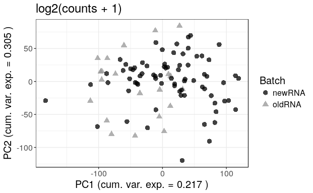

```r
# the count matrix itself does not have column names because of the way it was
# processed
colnames(log.count) <- colnames(vst.blind)[2:ncol(vst.blind)]
PCAPlotWrapper(exprs = log.count, plot.title = "log2(counts + 1)")
```

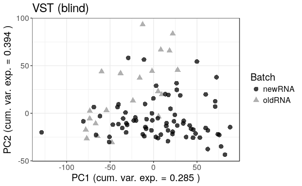

```r
PCAPlotWrapper(exprs = as.matrix(vst.blind[, 2:ncol(vst.blind)]),
               plot.title = "VST (blind)")
```

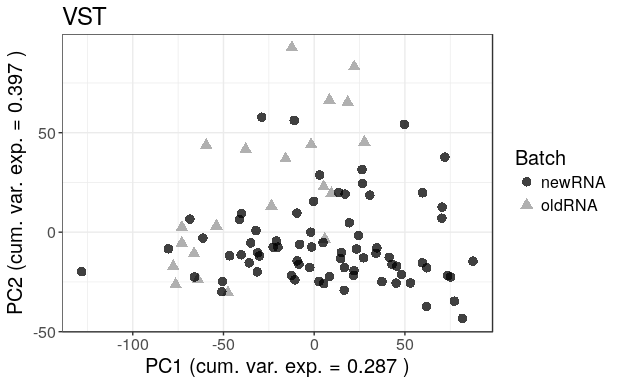

```r
PCAPlotWrapper(exprs = as.matrix(vst.design[, 2:ncol(vst.design)]),
               plot.title = "VST")
```

## Gene identifier conversion

All of the gene expression data from the RTX data set uses Ensembl gene IDs. PLIER, on the other hand, uses gene symbols. So we’ll need to do conversion. Let’s continue with variance stabilizing transformed data blinded to experimental design.

```r
mart <- biomaRt::useDataset("hsapiens_gene_ensembl",
                            biomaRt::useMart("ensembl"))
gene.df <- biomaRt::getBM(filters = "ensembl_gene_id",
                          attributes = c("ensembl_gene_id", "hgnc_symbol"),
                          values = vst.blind$Gene,
                          mart = mart)
```

[output not shown]

[output cut: 14 more lines]

[output not shown]

```r
# filter to remove genes without a gene symbol
gene.df <- gene.df %>% dplyr::filter(complete.cases(.))
```

```r
vst.blind.annot <- dplyr::inner_join(gene.df, vst.blind,
                                     by = c("ensembl_gene_id" = "Gene")) %>%
  dplyr::select(-ensembl_gene_id)
colnames(vst.blind.annot)[1] <- "Gene"
# aggregate duplicate gene symbols to gene mean
vst.agg <- PrepExpressionDF(vst.blind.annot)
```

## Read in recount2 PLIER model

```r
recount.plier <- readRDS(file.path("data", "recount2_PLIER_data",
                                   "recount_PLIER_model.RDS"))
```

Now filter the VST data to just the genes included in the recount2 model and prep it for use with various PLIER helper functions.

```r
vst.filt <- vst.agg %>%
  dplyr::filter(Gene %in% rownames(recount.plier$Z)) %>%
  tibble::column_to_rownames(var = "Gene")
```

```
Setting row names on a tibble is deprecated.
```

```r
# save to file
vst.file <- file.path("data", "rtx", "VST_blind_filtered.RDS")
saveRDS(vst.filt, vst.file)
```

```r
# let's remove the other VST data.frames or matrices and extraneous biomart
# objects
rm(vst.agg, vst.blind, vst.blind.annot, vst.design, mart, count.matrix)
```

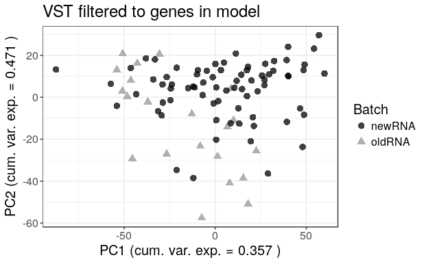

```r
PCAPlotWrapper(exprs = vst.filt,
               plot.title = "VST filtered to genes in model")
```

## PLIER

We’ll give PLIER row-normalized (z-scored) TPM data, as this is closest to the form we had the recount2 data in (RPKM) and, given this use case, the slight difference is unlikely to effect the results much.

```r
# get the gene-level TPM
rtx.tpm <- gene.summary$abundance
# we'll need to convert to HGNC gene symbol
rtx.tpm <- tibble::rownames_to_column(data.frame(rtx.tpm), var = "Gene")
rtx.tpm.annot <- dplyr::inner_join(gene.df, rtx.tpm,
                                    by = c("ensembl_gene_id" = "Gene")) %>%
  dplyr::select(-ensembl_gene_id)
colnames(rtx.tpm.annot) <- c("Gene", colnames(log.count))
# Aggregate duplicate gene identifiers to mean
rtx.agg <- PrepExpressionDF(rtx.tpm.annot)
# remove first row without identifier & write to file
rtx.agg <- rtx.agg %>%
  dplyr::filter(Gene != "")
readr::write_tsv(rtx.agg, file.path("data", "rtx", "tpm_aggregated.pcl"))
# get in expression matrix form
rtx.exprs <- as.matrix(rtx.agg %>% tibble::column_to_rownames(var = "Gene"))
```

```
Setting row names on a tibble is deprecated.
```

```r
# remove intermediates
rm(rtx.tpm.annot, rtx.tpm, rtx.agg)
```

```r
# remove genes that are all zero
remove.index <- which(apply(rtx.exprs, 1, function(x) all(x == 0)))
rtx.exprs <- rtx.exprs[-remove.index, ]
```

### Dataset-specific model

Training a PLIER model on this dataset

```r
rtx.plier <- PLIERNewData(exprs.mat = as.matrix(rtx.exprs))
```

```
Removing 1 pathways with too few genesComputing SVD
Done
```

```
[1] 58.36176
[1] "L2 is set to 58.361764073198"
[1] "L1 is set to 29.180882036599"
```

[output not shown]

[output cut: 54 more lines]

[output not shown]

```r
saveRDS(rtx.plier, file.path("data", "rtx", "RTX_PLIER_model.RDS"))
```

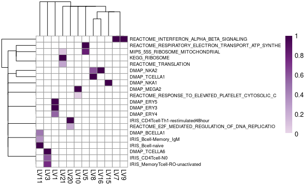

```r
PLIER::plotU(rtx.plier, auc.cutoff = 0.75, fontsize_row = 7,
             fontsize_col = 10)
```

There’s no neutrophil signature with `AUC > 0.75`. That’s interesting because this is a signal that we would expect in this whole blood data.

```r
pdf(file.path(plot.dir, "RTX_model_U_plot.pdf"))
PLIER::plotU(rtx.plier, auc.cutoff = 0.75, fontsize_row = 7,
             fontsize_col = 10)
dev.off()
```

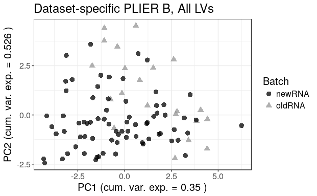

```r
PCAPlotWrapper(exprs = rtx.plier$B,
               plot.title = "Dataset-specific PLIER B, All LVs")
```

### recount2 model

```r
recount.b <- GetNewDataB(exprs.mat = as.matrix(rtx.exprs),
                         plier.model = recount.plier)
saveRDS(recount.b, file.path("data", "rtx", "RTX_recount2_B.RDS"))
```

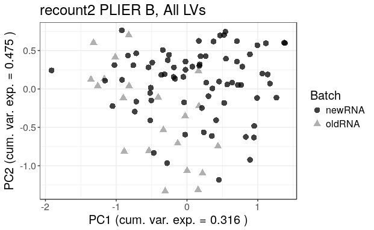

```r
PCAPlotWrapper(exprs = recount.b,
               plot.title = "recount2 PLIER B, All LVs")
```

## Final plotting

We’ll plot the following three plots, as these are the expected into any kind of supervised machine learning model (predicting response):

- VST expression data (only genes that overlap with recount2 PLIER model)
- Dataset-specific PLIER B, all LVs
- recount2 PLIER B, all LVs

```r
exprs.plot <- PCAPlotWrapper(exprs = vst.filt,
                             plot.title = "VST filtered to genes in model")
rtx.plot <- PCAPlotWrapper(exprs = rtx.plier$B,
                           plot.title = "Dataset-specific PLIER B, All LVs")
recount.plot <- PCAPlotWrapper(exprs = recount.b,
                               plot.title = "recount2 PLIER B, All LVs")
```

```r
pdf(file.path(plot.dir, "RTX_expected_ML_input_PCA.pdf"), height = 14,
    width = 7)
cowplot::plot_grid(exprs.plot, rtx.plot, recount.plot, align = "h", ncol = 1)
dev.off()
```